# Generative AI and the future of survey measurement

Generative AI and the future  
of survey measurement

Patrick Sturgis

Department of Methodology, London School of Economics

Presentation at Department of Methodology, Statistics and Data Science, Utrecht University · 8 October 2026

[figure not shown]

[figure not shown]

What I'll talk about today

LLMs may transform many parts of survey research. Their largest contribution may be to measurement.

Dynamic

Occupational coding

**SOCbot.** An LLM inside the survey assigns SOC2020 codes and asks follow-up questions where the answer leaves the code ambiguous.

Static

Questionnaire pretesting

**Cogbot.** LLMs simulate cognitive interviewing and expert review to find flaws in draft questions before fieldwork.

ESRC Survey Futures project *Integrating Generative AI in Question Design Evaluation and Testing* (ES/X014150/1) · with Tom Robinson (LSE) and Caroline Roberts (Lausanne)

SOCbot · Occupational coding

Occupation is hard to measure

Hundreds of occupations, many described in technical terms.

Measured with open questions on job title, tasks, industry and qualifications, then coded by hand after fieldwork.

SOC20 is hierarchical: 9 major groups, 26 sub-major groups, 104 minor groups and 412 four-digit unit groups, the most detailed level.

The procedure is costly, slow and error prone.

SOCbot · How it works

Code and probe on the fly

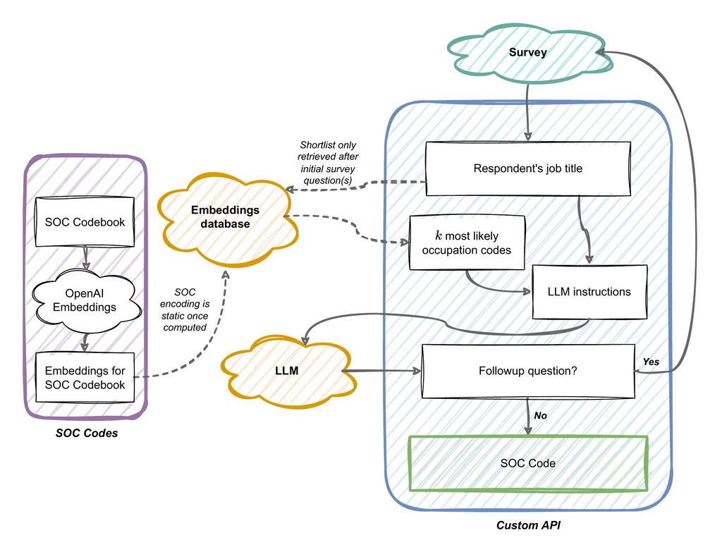

SOCbot · Study 1, archived responses

Agreement with production coding, Verian Public Voice

| Model | Major | Submajor | Minor | Unit |
| --- | --- | --- | --- | --- |
| o4-mini (original) | 0.797 | 0.754 | 0.709 | 0.599 |
| o3 (original) | 0.826 | 0.786 | 0.742 | 0.624 |
| Opus 4.6, no thinking | 0.809 | 0.768 | 0.726 | 0.614 |
| Opus 4.6, adaptive reasoning | 0.800 | 0.762 | 0.721 | 0.614 |
| GPT-5 | 0.811 | 0.769 | 0.728 | 0.608 |
| gpt-oss-120b (open-weight) | 0.778 | 0.733 | 0.675 | 0.558 |
| gpt-oss-20b (open-weight) | 0.770 | 0.724 | 0.671 | 0.547 |

n = 2,000, job title and industry, retrieval k = 10. Comparator is CASCOT plus human adjudication. Published human inter-coder agreement at unit level is 0.4–0.7.

SOCbot · Study 1

Unit group agreement across major groups

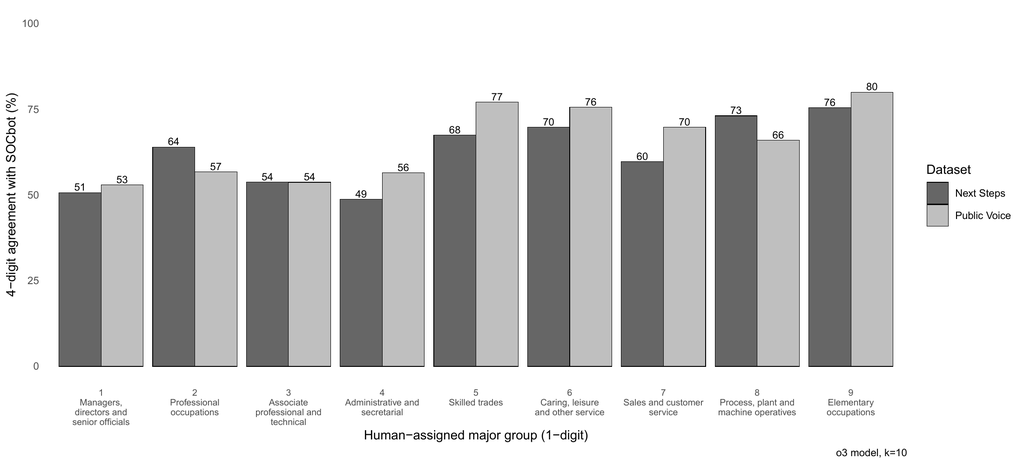

Unit-group agreement by the comparator’s major group. o3, k = 10.

SOCbot · Study 1

LLM confidence is a potential triage signal

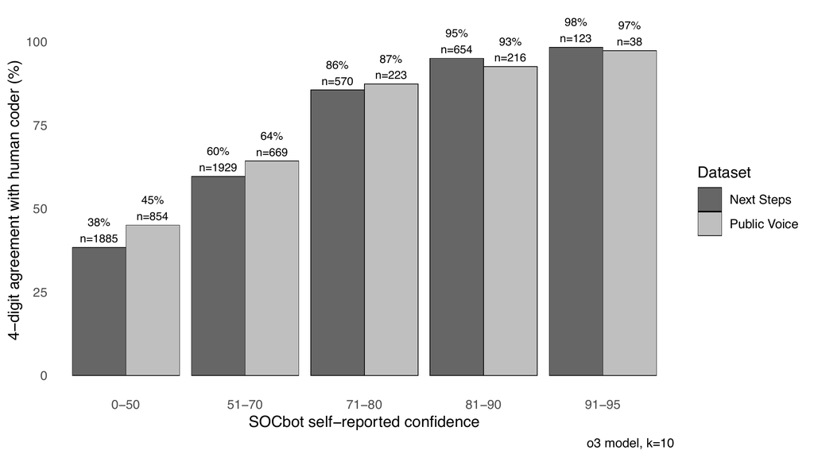

The LLM is prompted to return a confidence score from 0 to 100 with each SOC code it assigns. o3, k = 10.

SOCbot · Study 2, live survey

Verian UK Public Voice panel, July 2025. Response rate 20%.

Panel members had given their job title and industry in an earlier survey, and those answers had been coded to SOC2020 by human coders.

Each respondent was shown their previous job title and asked whether it was still correct.

If job title unchanged, dynamic SOCbot invoked.

The 1,093 respondents with an unchanged title give a before-and-after comparison against the same human code.

SOCbot · Study 2

Number of probes used by SOCbot

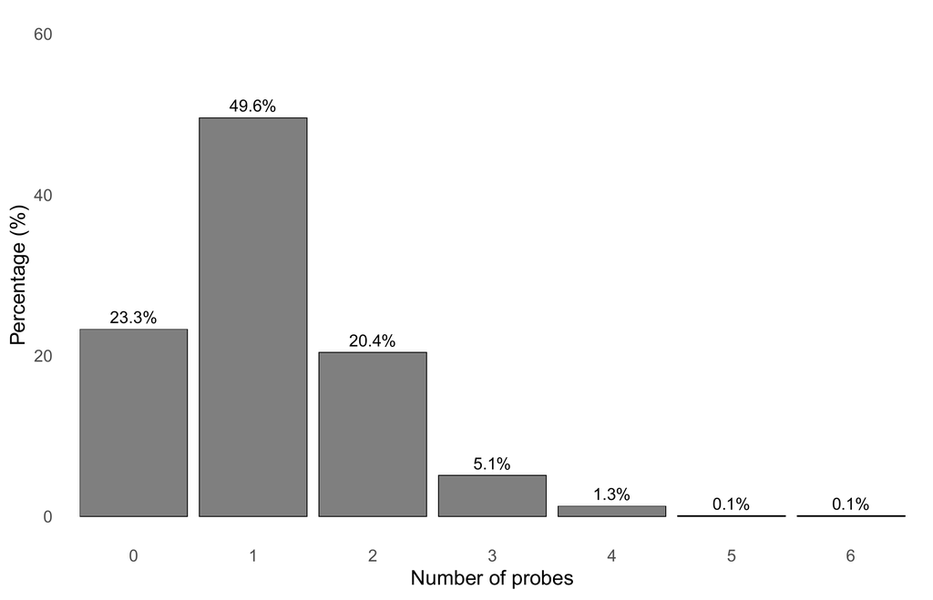

SOCbot · Study 2

What SOCbot chose to ask

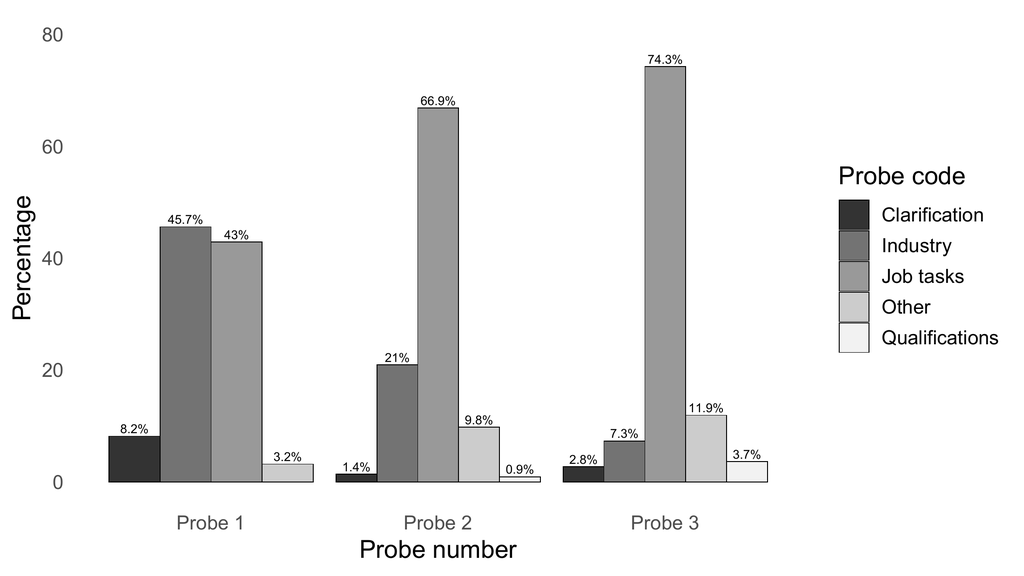

First probes split almost evenly between industry (46%) and job tasks (43%), with 8% asking for clarification of the title. By the third probe, 74% ask about tasks.

SOCbot · Study 2

Which coder is most accurate?

1,093 respondents with an unchanged job title. Human = CASCOT-assisted human coding.

Dynamic SOCbot has the most, and most tailored, information, so on theoretical grounds it should be the most accurate coder.

The coder that agrees more with the best-informed coder is the more valid one (Cronbach and Meehl 1955). Static SOCbot agrees with it on 58% of cases, human coding on 43%.

Inferred accuracy ordering: dynamic SOCbot, then static SOCbot, then human / CASCOT coding.

SOCbot · Conclusions

Coding quality comparable to, or better than, human coders.

Much cheaper and quicker than post-fieldwork office coding.

Open-weight models work, so data need not leave the organisation.

Tailored probes reduce respondent burden.

The confidence rating carries signal for triage to human review.

Cogbot · Question pretesting

Question pretesting

Pretesting is essential to good question design.

The main methods are cognitive interviewing and expert review.

Both are costly and time-consuming, and rely on scarce human expertise.

Many questions go to field untested.

Our paper: can LLMs detect problems in draft survey questions, as a complement to human pretesting?

Cogbot · How it works

Synthetic cognitive interview pipeline

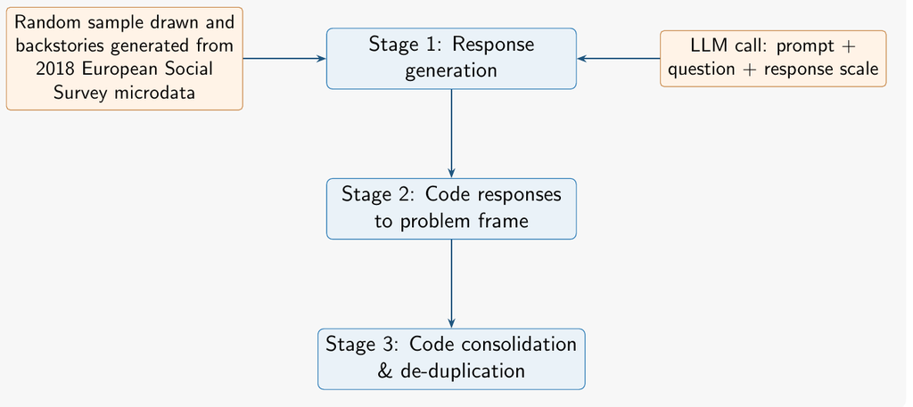

30 backstories per run, drawn from 2,204 ESS 2018 UK records.

Cogbot · How it works

Expert review pipeline

Three independent LLM reviewers, each prompted to act as a survey methodologist, assess the question directly.

Each reviewer lists problems and rates severity from 1 (negligible) to 10 (answer rendered meaningless).

A synthesis step merges duplicates across reviewers and averages severity.

Cogbot · Design

Six prompt variants

Simulated cognitive testing

**CI-Open** · free think-aloud

**CI-Structured** · comprehension, retrieval, judgement, response, with no problem types named

**CI-List** · the same stages plus named problem types

Expert review, three reviewers

**ER-Open** · identify problems freely

**ER-Restrained** · report only consequential problems; return an empty list if the question is sound

**ER-Checklist** · evaluate against seven named problem types

Cogbot · Design

A constructed answer key

27 questions: 20 conventional questions with one to three deliberately embedded problems each (48 known problems, eight types), plus 7 well-tested ESS core items as controls.

Detection is the proportion of the 48 known problems identified.

Provisional false positives are findings per question not matched to the key. The key is not exhaustive, so some are genuine problems.

Main runs on GPT-4o, replicated on Llama-3.3-70B, Qwen3-32B and Claude Opus 5.

Cogbot · Example output

“Overall, how satisfied are you with your terms of employment?”

Three embedded problems: vague wording, an asymmetric scale, a presupposition of current employment

Synthetic respondent 2

Retired, former shopkeeper. “Being retired and a former shopkeeper, I’m not currently employed in the traditional sense, so the question feels a bit out of place for me. However, I can think back to when I was actively running my shop. […] Since I’m retired, none of these apply directly to me anymore.”

Synthetic respondent 24

Gardener, female, 59. “I start thinking about what ‘terms of employment’ actually means for me. I assume it’s about my contract, pay, working conditions, hours, and maybe benefits like holiday or sick leave. […] Considering everything, I would say I’m ‘Fairly satisfied.’”

Expert reviewer

Comprehension. “The phrase ‘terms of employment’ may be interpreted differently by respondents, potentially including salary, benefits, work hours, or job security.”  
Presupposition. “The question assumes that respondents have defined and clear terms of employment, which may not be true for all, such as temporary or freelance workers.”

Cogbot · Results on GPT-4o

Detection and provisional false positives

| Configuration | Detection | FP per flawed item | FP per ESS item | Detection severity ≥5 | FP per flawed severity ≥5 | FP per ESS severity ≥5 |
| --- | --- | --- | --- | --- | --- | --- |
| CI-List | 75% | 1.8 | 1.6 | 65% | 1.5 | 1.0 |
| ER-Checklist | 73% | 1.4 | 2.3 | 60% | 1.1 | 0.6 |
| ER-Open | 69% | 1.4 | 3.1 | 69% | 1.4 | 3.1 |
| CI-Open | 60% | 1.4 | 1.4 | 50% | 1.0 | 1.0 |
| ER-Restrained | 48% | 0.8 | 0.3 | 46% | 0.6 | 0.3 |
| CI-Structured | 31% | 0.6 | 0.7 | 25% | 0.5 | 0.6 |

Cogbot · Results on GPT-4o

The two approaches find different problems

| Problem type | Known problems | CI-List | ER-Checklist |
| --- | --- | --- | --- |
| Double-barrelled | 6 | 100% | 100% |
| Presupposition | 9 | 44% | 89% |
| Vague or ambiguous | 9 | 78% | 67% |
| Response mapping | 7 | 71% | 43% |
| Retrieval or recall | 5 | 100% | 100% |
| Leading or loaded | 5 | 100% | 80% |
| Sensitivity | 4 | 50% | 50% |
| Complex syntax | 3 | 67% | 33% |

Small numbers of known problems per category.

Cogbot · Four LLMs

Model choice changes the results

| Configuration | GPT-4o | Llama-3.3-70B | Qwen3-32B | Opus 5 |
| --- | --- | --- | --- | --- |
| CI-Open | 60% (1.4) | 73% (5.4) | 79% (6.7) | 94% (9.7) |
| CI-Structured | 31% (0.7) | 65% (4.1) | 73% (5.4) | 92% (9.1) |
| CI-List | 75% (1.6) | 88% (5.4) | 75% (7.1) | 88% (8.9) |
| ER-Checklist | 73% (2.3) | 79% (3.4) | 73% (2.7) | 100% (8.4) |
| ER-Open | 69% (3.1) | 67% (3.1) | 63% (1.7) | 100% (8.4) |
| ER-Restrained | 48% (0.3) | 46% (0.3) | 4% (0.1) | 94% (5.3) |

Detection, with provisional false positives per ESS control item in brackets. One run per cell. Open-weight runs March 2026, Opus 5 August 2026.

Cogbot · Four LLMs

Filtering on severity changes the picture

| Configuration | GPT-4o | Llama-3.3-70B | Qwen3-32B | Opus 5 |
| --- | --- | --- | --- | --- |
| CI-Open | 50% (1.0) | 73% (4.7) | 44% (2.1) | 60% (2.0) |
| CI-Structured | 25% (0.6) | 56% (3.9) | 46% (0.7) | 52% (1.1) |
| CI-List | 65% (1.0) | 79% (4.4) | 56% (3.1) | 63% (1.7) |
| ER-Checklist | 60% (0.6) | 65% (1.9) | 33% (0.4) | 83% (1.4) |
| ER-Open | 69% (3.1) | 67% (3.0) | 56% (1.4) | 79% (3.7) |
| ER-Restrained | 46% (0.3) | 44% (0.1) | 4% (0.1) | 60% (0.9) |

Findings with pipeline-assigned severity ≥5 only. Detection, with provisional false positives per ESS control item in brackets.

Cogbot · Human assessment

Are unmatched findings false positives?

Two questionnaire-design specialists rated 79 unmatched findings on a 1–5 scale, blind to the answer key. A finding counted as genuine only if both rated it 4 or 5.

| Findings on | CI-List | ER-Checklist |
| --- | --- | --- |
| Flawed questions | 19 of 29 (66%) | 8 of 24 (33%) |
| ESS controls | 0 of 9 | 2 of 17 |

Many unmatched problems on flawed questions are real problems missing from the key, so the false positive rates are upper bounds. Most on the control items are spurious.

Cogbot · Conclusions

The best configurations detected about three quarters of the embedded problems.

False positive rates are substantial, though many are genuine problems missing from the key.

Detection depends on prompt design and on the LLM.

Cognitive testing and expert review find different problems.

Fast and cheap: a 20-item questionnaire in under an hour for under $10.

Best used as early-stage screening. Human expert review and cognitive interviewing remain necessary.

Papers

Sturgis, P., Robinson, T. S., Fung, L. and Roberts, C. (2026). SOCbot: Using Large Language Models to dynamically measure and classify occupations in surveys. *Sociological Methods & Research*, online first.  
https://journals.sagepub.com/doi/full/10.1177/00491241261461516

Sturgis, P., Roberts, C. and Robinson, T. (2026). LLMs for survey pretesting: How well can large language models identify flaws in survey questions? *Survey Futures Working Paper 15*, April 2026.  
https://surveyfutures.net/wp-content/uploads/2026/04/working-paper-15-llms-for-survey-pretesting.pdf

Roberts, C., Sturgis, P., McGee, A., Hamlyn, R., Minichino, M. and Robinson, T. (2026). Survey question evaluation at scale: Applying large language models to the QAS-99. *Survey Futures Working Paper 22*, July 2026.  
https://surveyfutures.net/wp-content/uploads/2026/07/working-paper-22-survey-question-evaluation-scale-applying-llm-to-qas-99.pdf

Patrick Sturgis · p.sturgis@lse.ac.uk